# ADA_P5

Zane Hassoun

3/1/2022

#### Penalised Regression Splines using many covariates

1. Fit a quasi-Poisson penalised spline based GAM (mgcv::gam(.)) as follows. Print out a summary of the model and inspect the results

```r
#Penalised Regression Spline

PRS = mgcv::gam(Nhat ~ s(XPos) + s(YPos) + s(Depth) + Impact,
data=df, family=quasipoisson, offset=log(Area))

summary(PRS)
```

```
##
## Family: quasipoisson
## Link function: log
##
## Formula:
## Nhat ~ s(XPos) + s(YPos) + s(Depth) + Impact
##
## Parametric coefficients:
##             Estimate Std. Error t value Pr(>|t|)
## (Intercept)   2.6743     0.3273   8.171 3.19e-16 ***
## Impact1       0.2547     0.0316   8.059 7.99e-16 ***
## ---
## Signif. codes:  0 '***' 0.001 '**' 0.01 '*' 0.05 '.' 0.1 ' ' 1
##
## Approximate significance of smooth terms:
##            edf Ref.df      F p-value
## s(XPos)  8.975  9.000  89.29  <2e-16 ***
## s(YPos)  8.981  9.000  84.59  <2e-16 ***
## s(Depth) 8.072  8.315 105.26  <2e-16 ***
## ---
## Signif. codes:  0 '***' 0.001 '**' 0.01 '*' 0.05 '.' 0.1 ' ' 1
##
## R-sq.(adj) =  0.0347   Deviance explained = 19.2%
## GCV = 250.16  Scale est. = 393.45    n = 27854
```

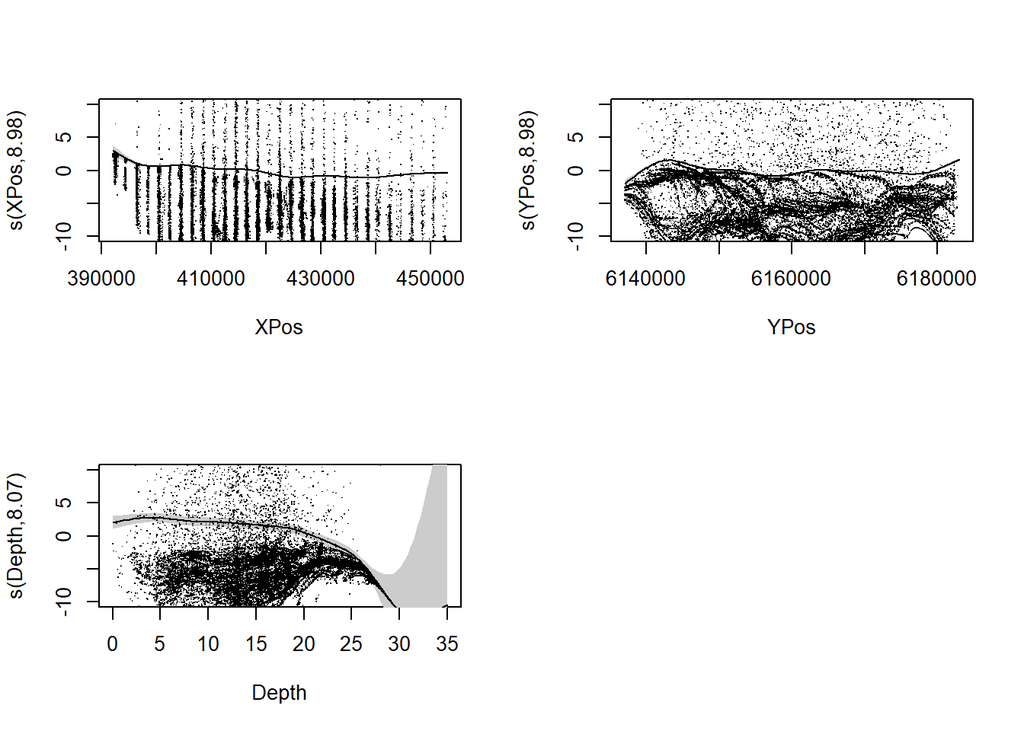

```r
par(mfrow=c(2,2))
plot(PRS, shade = T, residuals = T, ylim=c(-10,10))
```

3. Visually compare the Depth relationship obtained using the PRS model to a model that uses a B-spline basis function instead with just one knot at 20m

```r
PRS_B = stats::update(PRS, .~. -s(Depth) + splines::bs(Depth, knots = 20))
summary(PRS_B)
```

```
##
## Family: quasipoisson
## Link function: log
##
## Formula:
## Nhat ~ s(XPos) + s(YPos) + Impact + splines::bs(Depth, knots = 20)
##
## Parametric coefficients:
##                                 Estimate Std. Error t value Pr(>|t|)
## (Intercept)                       6.3269     0.1102  57.420   <2e-16 ***
## Impact1                           0.2539     0.0159  15.970   <2e-16 ***
## splines::bs(Depth, knots = 20)1  -2.1888     0.1970 -11.110   <2e-16 ***
## splines::bs(Depth, knots = 20)2   0.3245     0.1451   2.236   0.0253 *
## splines::bs(Depth, knots = 20)3  -8.8092     0.3168 -27.806   <2e-16 ***
## splines::bs(Depth, knots = 20)4 -37.8328     3.5819 -10.562   <2e-16 ***
## ---
## Signif. codes:  0 '***' 0.001 '**' 0.01 '*' 0.05 '.' 0.1 ' ' 1
##
## Approximate significance of smooth terms:
##           edf Ref.df     F p-value
## s(XPos) 8.963  8.999 355.1  <2e-16 ***
## s(YPos) 8.983  9.000 337.3  <2e-16 ***
## ---
## Signif. codes:  0 '***' 0.001 '**' 0.01 '*' 0.05 '.' 0.1 ' ' 1
##
## R-sq.(adj) =  0.0341   Deviance explained = 19.1%
## GCV = 250.59  Scale est. = 99.784    n = 27854
```

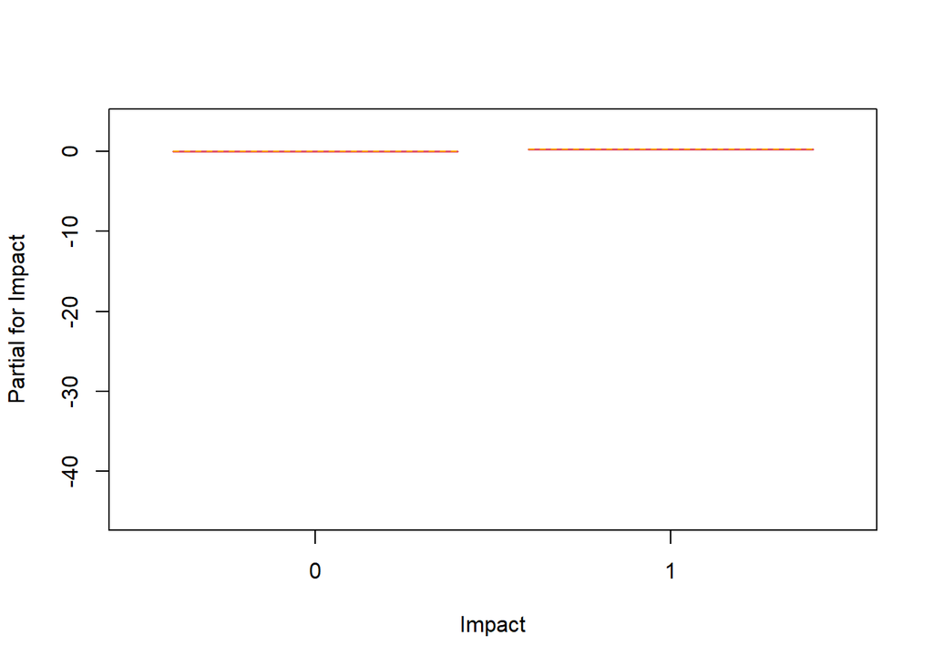

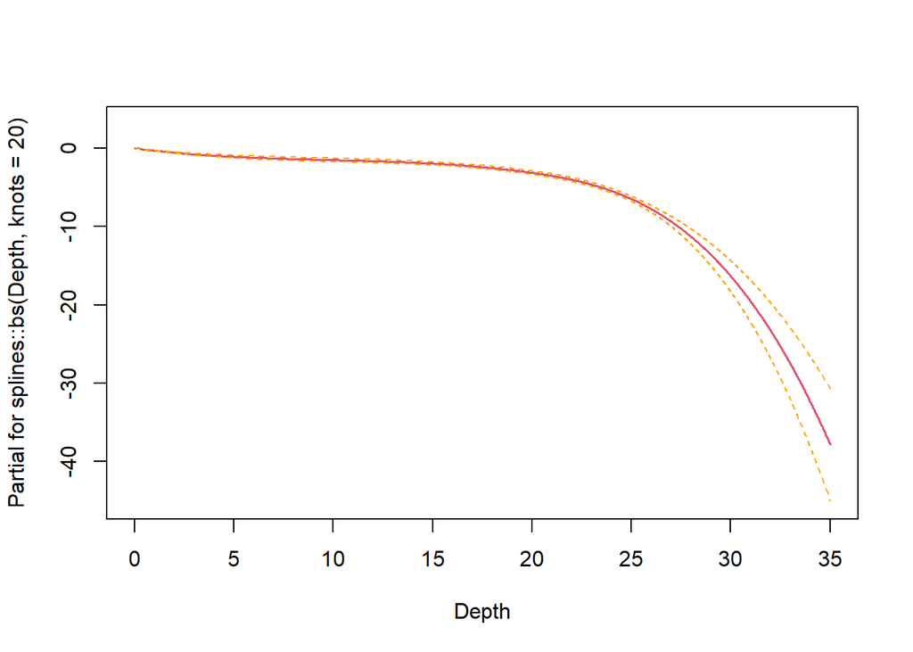

```r
stats::termplot(PRS_B, se=T)
```

4. Carry out model selection on the terms in the working GAM (i.e. the PRS model fitted in 1.) using the dredge function in the MuMIn library. Use QAIC to rank the different models. See lecture notes Section 5.5 for a reminder of how to use the dredge function (the overdispersion parameter estimate can be found in PRS$scale).

```r
library(MuMIn)
options(na.action="na.fail") # fail-safe
PRS_Q = update(PRS, family = "poisson")
head(dredge(PRS_Q,
            rank = "QAIC",
            chat = PRS$scale))
```

```
## Fixed term is "(Intercept)"
```

```
## Global model call: mgcv::gam(formula = Nhat ~ s(XPos) + s(YPos) + s(Depth) + Impact,
##     family = "poisson", data = df, offset = log(Area))
## ---
## Model selection table
##    (Int) Imp s(Dpt) s(XPs) s(YPs) df   logLik    QAIC   delta weight
## 16 2.696   +      +      +      + 28 -3494764 17824.4    0.00      1
## 15 2.838          +      +      + 27 -3507645 17887.8   63.43      0
## 8  2.813   +      +      +        19 -3651125 18601.2  776.82      0
## 7  2.977          +      +        18 -3668453 18687.3  862.86      0
## 12 2.897   +      +             + 19 -3675046 18722.8  898.36      0
## 11 3.084          +             + 18 -3698044 18837.7 1013.26      0
## Models ranked by QAIC(x, chat = 393.454018449893)
```

5. Download HornsRevPredictionData.csv from Moodle. This file contains a fine grid of XPos/YPos values and corresponding Depth measurements. Use the “best” model identified in 4. to predict over this fine grid and produce a spatial plot of all the results (pre/post-impact both on the link and response scale).

```r
predData = read.csv("C:/Users/zaneh/Downloads/HornsRevPredictionData.csv")

# Predict on the link scale
NhatPredLink = predict(PRS, newdata=predData,
se=T, type="link")
# Predict on the response scale
NhatPredRes = predict(PRS, newdata=predData,
se=T, type="response")
```

Predictions Quilt Plots

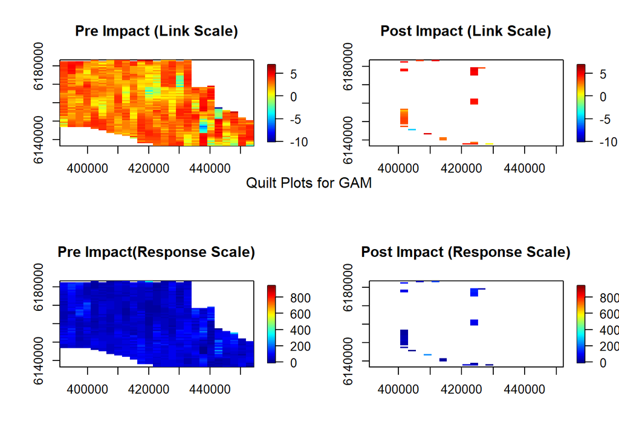

```r
par(mfrow=c(2,2))

# Loop across all phases


for(phase in c(0,1)){
  fields::quilt.plot(df$XPos[which(df$Impact == phase)],
                       df$YPos[which(df$Impact == phase)],
                       NhatPredLink$fit[which(df$Impact == phase)],
                       nrow=25, ncol=60,
                       zlim=range(NhatPredLink$fit),
                       main=paste(ifelse(phase == 0, "Pre Impact (Link Scale)", "Post Impact (Link Scale)")))
}
for(phase in c(0,1)){
  iteration = df$Impact %in% phase
  fields::quilt.plot(df$XPos[which(df$Impact == phase)],
                       df$YPos[which(df$Impact == phase)],
                       NhatPredRes$fit[which(df$Impact == phase)],
                       nrow=25, ncol=60,
                       zlim=range(NhatPredRes$fit),
                       main=paste(ifelse(phase == 0, "Pre Impact(Response Scale)", "Post Impact (Response Scale)")))
}

mtext("Quilt Plots for GAM", side = 3, line = -13, outer = TRUE)
```

#### Fitting a GAM with multiple Covariates

```r
PRS_Int = mgcv::gam(Nhat ~ s(XPos, by=Impact) + s(YPos) + s(Depth) + Impact,
                    data=df,
                    family=quasipoisson,
                    offset=log(Area))
summary(PRS_Int)
```

```
##
## Family: quasipoisson
## Link function: log
##
## Formula:
## Nhat ~ s(XPos, by = Impact) + s(YPos) + s(Depth) + Impact
##
## Parametric coefficients:
##             Estimate Std. Error t value Pr(>|t|)
## (Intercept)  -4.1859     0.2051  -20.41   <2e-16 ***
## Impact1       7.0887     0.1914   37.03   <2e-16 ***
## ---
## Signif. codes:  0 '***' 0.001 '**' 0.01 '*' 0.05 '.' 0.1 ' ' 1
##
## Approximate significance of smooth terms:
##                   edf Ref.df    F p-value
## s(XPos):Impact0 8.985  9.000 2585  <2e-16 ***
## s(XPos):Impact1 8.986  9.000 2530  <2e-16 ***
## s(YPos)         8.983  9.000 2165  <2e-16 ***
## s(Depth)        8.109  8.357 2597  <2e-16 ***
## ---
## Signif. codes:  0 '***' 0.001 '**' 0.01 '*' 0.05 '.' 0.1 ' ' 1
##
## R-sq.(adj) =  0.0554   Deviance explained = 24.9%
## GCV = 232.67  Scale est. = 15.02     n = 27854
```

```r
NhatPredLink_2 = predict(PRS_Int, newdata=predData,
se=T, type="link")
# Predict on the response scale
NhatPredRes_2 = predict(PRS_Int, newdata=predData,
se=T, type="response")
```

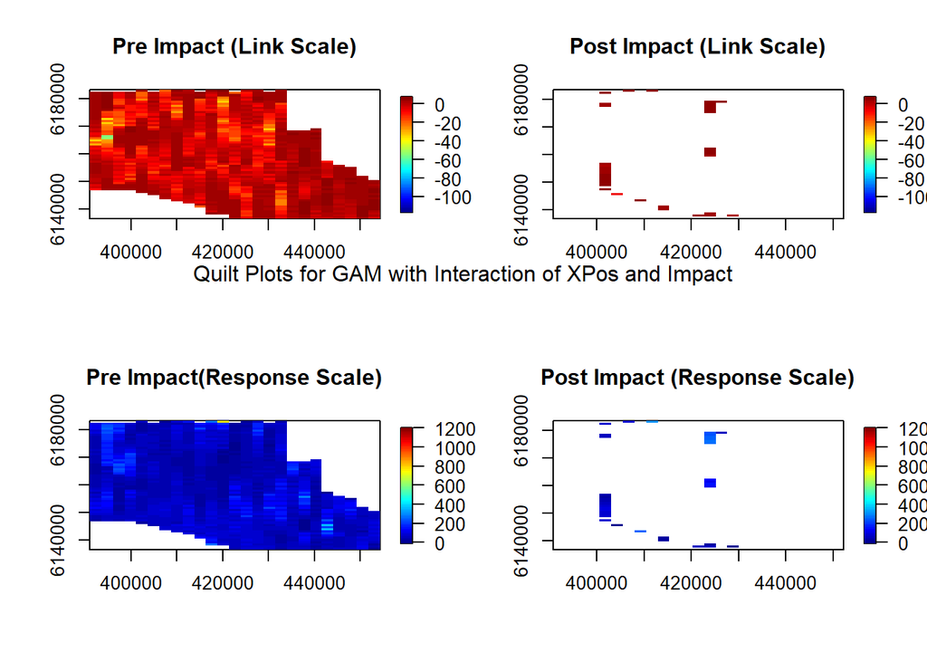

```r
par(mfrow=c(2,2))

# Loop across all phases


for(phase in c(0,1)){
  fields::quilt.plot(df$XPos[which(df$Impact == phase)],
                       df$YPos[which(df$Impact == phase)],
                       NhatPredLink_2$fit[which(df$Impact == phase)],
                       nrow=25, ncol=60,
                       zlim=range(NhatPredLink_2$fit),
                       main=paste(ifelse(phase == 0, "Pre Impact (Link Scale)", "Post Impact (Link Scale)")))
}
for(phase in c(0,1)){
  iteration = df$Impact %in% phase
  fields::quilt.plot(df$XPos[which(df$Impact == phase)],
                       df$YPos[which(df$Impact == phase)],
                       NhatPredRes_2$fit[which(df$Impact == phase)],
                       nrow=25, ncol=60,
                       zlim=range(NhatPredRes_2$fit),
                       main=paste(ifelse(phase == 0, "Pre Impact(Response Scale)", "Post Impact (Response Scale)")))
}

mtext("Quilt Plots for GAM with Interaction of XPos and Impact", side = 3, line = -13, outer = TRUE)
```

```r
runs.test(residuals(PRS_Int, type = 'pearson'))
```

```
##
##  Runs Test - Two sided
##
## data:  residuals(PRS_Int, type = "pearson")
## Standardized Runs Statistic = -122.92, p-value < 2.2e-16
```